# Yuba River

Mark Tompkins

July 2024

## Future Data Improvements

None expected.

## Notes

Updated spawning, instream rearing, and floodplain rearing were provided for fall and spring run and were derived from Habitat Suitability Indices (HSI). Earlier data, which we are still using for steelhead, were derived as weighted usable habitat (WUA). We took the updated fall and spring run (HSI derived) and transformed it to a habitat rate of suitable area per length of river, which is converted to suitable area in the structure of the model logic. We needed to do this to align data for all runs.

## Instream Spawning and Rearing Habitat

#### Chinook

**Data Source:** Updated spawning, instream rearing, and floodplain rearing were provided directly by Morgan Neal (HDR, Inc.) as part of an analysis to account for projected suitable habitat created by Health Rivers and Landscapes (HRL) projects. These data were provided in an excel format stored in `data-raw/watershed/yuba/data/HydraulicHabFlow_LYR_7-15-2024.xlsx`.

Water depths and water velocities in the lower Yuba River were simulated by using a TUFLOW HPC 2D hydrodynamic model of the lower Yuba River using a 2017 digital elevation model (DEM). The 2017 DEM was developed subsequent to high flows that occurred during Winter of 2017 using Airborne Light Detection and Ranging (LiDAR), boat-based multibeam and single beam echosounding, and ground-based topographic surveying with Real-time kinematic (RTK) Global Positioning System (GPS) and robotic total stationing. The 2D model was run with a 3’x3’ computation mesh for flows <= 30,000 cfs and a 10’x10’ mesh for flows > 30,000 to 110,400 cfs. Detailed discussion of the calibration, validation and deployment of the 2017 2D model of the lower Yuba River is provided in Pasternack (in prep) and the documentation of the methodologies employed to produce the 2017 DEM is provided in Silva and Pasternack (2018).

Hydraulic criteria applied to spawning, instream rearing, and floodplain rearing to get the total suitable habitat area relationships:

|  | Spawning | Instream Rearing |
| --- | --- | --- |
| Depth (feet) | 1.0 - 2.5 | 0.5 - 4.0 |
| Velocity (feet/s) | 1.0 - 4.0 | 0.0 - 3.0 |

Spawning substrate criteria and data:

- Dominant substrate `2-10` cm
- Mean diameter substrate data based on 2010-2011 and 2018-2020 surveys within the bankfull channel (`5,000` cfs extent)

Existing condition instream and floodplain rearing habitat:

- Delineation of instream and floodplain based on `1,500` cfs wetted extent below DPD (as modified by Hallwood As-Built condition) and `1,750` cfs wetted extent above DPD
- Based on preliminary YWA analysis of flow that meets the intent of Meaningful Floodplain Event (MFE) criteria during `80%` of years using modeled daily hydrology below DPD and below Deer Creek.

#### Steelhead

**Data Source:** [Spawning FWS 2010](https://www.fws.gov/lodi/instream-flow/Documents/Yuba%20River%20Spawning%20Final%20Report.pdf) (pgs 59-61) and [Rearing FWS 2010](https://www.fws.gov/lodi/instream-flow/Documents/Yuba%20River%20Rearing%20Final%20Report.pdf) (pgs 74-76)

The instream spawning and rearing habitat for Steelhead in the Yuba River are based on data from the Fish and Wildlife Service (FWS) flow-habitat relationship final reports. A 2-dimensional hydraulic and habitat model called River2D was used to model available spawning and rearing habitat. The FWS instream spawning and rearing data were provided by Mark Gard from the California Department of Fish and Wildlife in a [spreadsheet](https://cvpiahabitat-r-package.s3-us-west-2.amazonaws.com/IFIMWUA.xlsx). Mark Gard instructed us to use cells A4:H33 and A39:H68 of the ‘Yuba’ tab within the spreadsheet, representing the Englebright to Daguerre Segment (12.7 miles) and the Daguerre to Feather Segment (11.4 miles), respectively. For adult Steelhead, Mark Gard instructed us to use cells A73:B100 of the ‘Yuba’ tab within the spreadsheet.

### Spawning and Rearing Data

#### Steelhead

The instream spawning and rearing habitat data described above for Steelhead (ST) are combined for use in the Decision Support Model (DSM) in the following format. Units are in square feet per 1000 feet.

#### Chinook

Instream spawning and rearing habitat data provided for Chinook are provided in units of suitable acres. They were converted to square feet per 1000 feet to align with previous versions. Floodplain habitat were kept in acres.

Header Descriptions: flow_cfs = flow in cubic feet per second, FR_spawn_wua = Fall Run Chinook Spawning WUA, FR_fry_wua = Fall Run Chinook Fry WUA, FR_juv_wua = Fall Run Chinook Juvenile WUA, SR_spawn_wua = Spring Run Chinook Spawning WUA, ST_spawn_wua = Steelhead Spawning WUA, ST_fry_wua = Steelhead Fry WUA, ST_juv_wua = Steelhead Juvenile WUA, ST_adult_wua = Steelhead Adult WUA, watershed = section of stream modeled for CVPIA SDM

| flow_cfs | ST_spawn_wua | ST_fry_wua | ST_juv_wua | ST_adult_wua | watershed | SR_spawn_wua | FR_spawn_wua | FR_fry_wua | FR_juv_wua |
| --- | --- | --- | --- | --- | --- | --- | --- | --- | --- |
| 150 | 63.60021 | 2472.573 | 1115.130 | NA | Yuba River | 10480.69 | 10480.69 | 55590.13 | 55590.13 |
| 250 | 162.49371 | 2718.746 | 1414.411 | NA | Yuba River | 10480.69 | 10480.69 | 55590.13 | 55590.13 |
| 300 | 223.07620 | 2846.064 | 1551.380 | 75292.67 | Yuba River | 18766.09 | 18766.09 | 110047.21 | 110047.21 |
| 350 | 286.41708 | 2880.195 | 1667.232 | 77960.78 | Yuba River | 20536.48 | 20536.48 | 111251.07 | 111251.07 |
| 400 | 1079.34899 | 7674.502 | 3820.689 | 79850.13 | Yuba River | 22306.87 | 22306.87 | 112454.94 | 112454.94 |

*… with 56 more rows*

### Spawning WUA

The following plot shows the weighted usable spawning area (WUA) in square feet per thousand feet for Fall Run Chinook Salmon, Spring Run Chinook Salmon, and Steelhead. These area per length rates are multiplied by the total spawning reach length mapped by the Science Integration Team (SIT) to estimate available habitat.

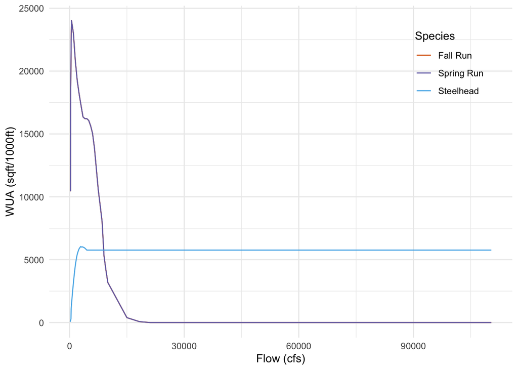

### Rearing WUA

The following plot shows the rearing WUA in square feet per thousand feet for Fall Run Chinook Salmon and Steelhead fry and juvenile. These rates are multiplied by the total rearing reach length mapped by the SIT to estimate available habitat.

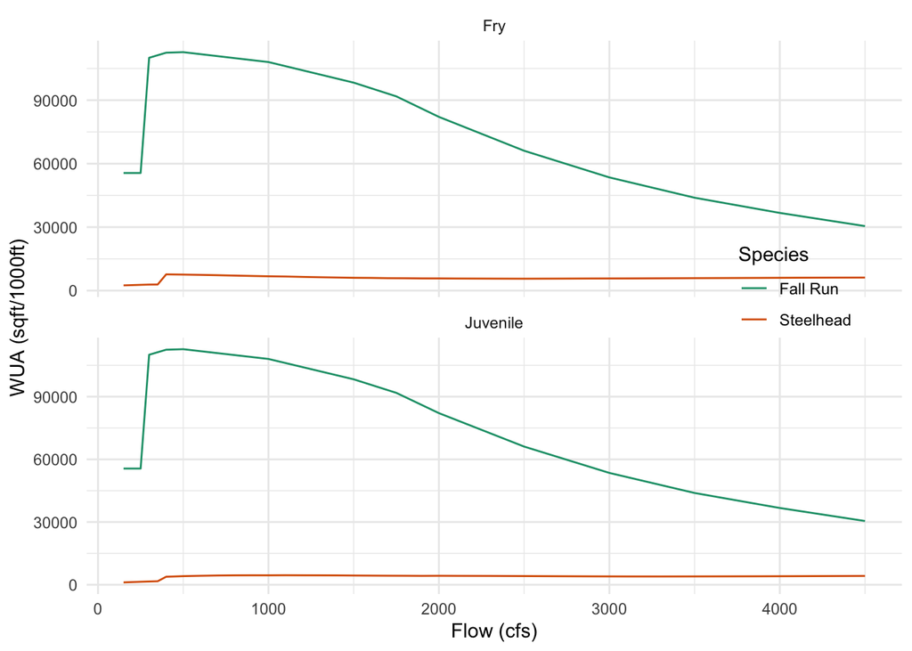

## Floodplain Rearing Habitat

Updated data for Fall Run floodplain rearing habitat were received from Morgan Neal (HDR Inc.). Spring Run and Steelhead were updated to use the same floodplain rearing habitat to flow relationship as fall run. This methodology is consistent with how Yuba River floodplain rearing habitat was modeled in CVPIA DSMhabitat.

## Floodplain Data

The areas represent total inundated area in acres.

Header Descriptions: flow_cfs = flow in cubic feet per second, FR_floodplain_acres = Fall Run Chinook floodplain acres, SR_floodplain_acres = Spring Run Chinook floodplain acres, ST_floodplain_acres = Steelhead floodplain acres, watershed = section of stream modeled for CVPIA SDM

| flow_cfs | FR_floodplain_acres | SR_floodplain_acres | ST_floodplain_acres | watershed |
| --- | --- | --- | --- | --- |
| 300 | 0 | 0 | 0 | Yuba River |
| 400 | 0 | 0 | 0 | Yuba River |
| 500 | 0 | 0 | 0 | Yuba River |
| 1000 | 0 | 0 | 0 | Yuba River |
| 1500 | 0 | 0 | 0 | Yuba River |

*… with 31 more rows*

## Floodplain Plot

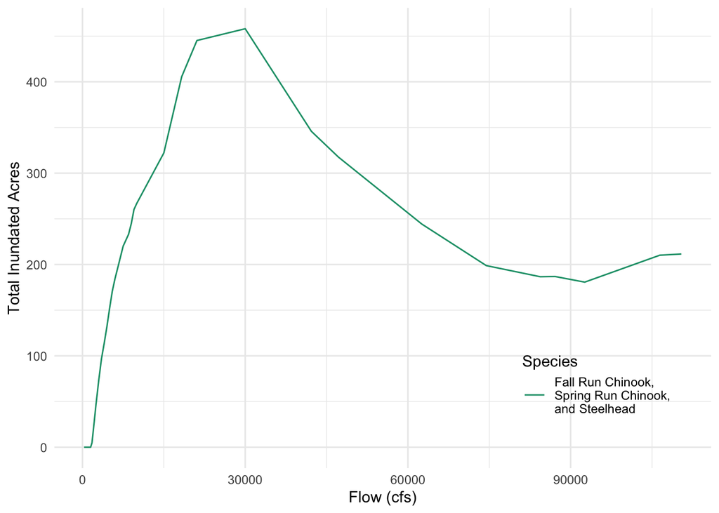